# Regulation of intestinal immune homeostasis and inflammatory response by enteric glia

[Link to Article](https://www.nature.com/articles/s41586-021-04006-z/?target=_blank)

Fränze Progatzky, Michael Shapiro, Song Hui Chng, Bethania Garcia-Cassani, Cajsa Helena Classon, Selin Sevgi, Anna Laddach, Ana Carina Bon-Frauches, Reena Lasrado, Maryam Rahim, Eleni-Maria Amaniti, Stefan Boeing, Kathleen Shah, Lewis J. Entwistle, Alejandro Suárez-Bonnet, Mark S. Wilson, Brigitta Stockinger and Vassilis Pachnis

Compiled: October 20, 2021

Abstract

“Tissue maintenance and repair depend on the integrated activity of multiple cell types. Whereas the contributions of epithelial, immune and stromal cells in intestinal tissue integrity are well understood, the role of intrinsic neuroglia networks remains largely unknown. Here we uncover important roles of enteric glial cells (EGCs) in intestinal homeostasis, immunity and tissue repair. We demonstrate that infection of mice with Heligmosomoides polygyrus leads to enteric gliosis and the upregulation of an interferon gamma (IFNγ) gene signature. IFNγ-dependent gene modules were also induced in EGCs from patients with inflammatory bowel disease. Single-cell transcriptomics analysis of the tunica muscularis (TM) showed that glia-specific abrogation of IFNγ signalling leads to tissue-wide activation of pro-inflammatory transcriptional programs. Furthermore, disruption of the IFNγ–EGC signalling axis enhanced the inflammatory and granulomatous response of the TM to helminths. Mechanistically, we show that the upregulation of Cxcl10 is an early immediate response of EGCs to IFNγ signalling and provide evidence that this chemokine and the downstream amplification of IFNγ signalling in the TM are required for a measured inflammatory response to helminths and resolution of the granulomatous pathology. Our study demonstrates that IFNγ signalling in enteric glia is central to intestinal homeostasis and reveals critical roles of the IFNγ–EGC–CXCL10 axis in immune response and tissue repair after infectious challenge.”

# Interactive Article Figure Supplement for Single-cell Experiments

Links to interactiver versions of all figures can be found in the respective figure legends or can be accessed directly here:

**[H.Poly Single-cell Experiment Viewer](https://bioinformatics.crick.ac.uk/shiny/users/boeings/EGCsHPoly_app/?target=_blank)**  
**[WT/MT Infected/Uninfected Single-cell Experiment Viewer](https://bioinformatics.crick.ac.uk/shiny/users/boeings/GliaIfngrKO_app/?target=_blank)**

## H.Polygyrus Single-cell Study

```r
cat(paste(knitr::knit(text = chnkVec, quiet = T), collapse = "\n"))
```

### Figure_1g

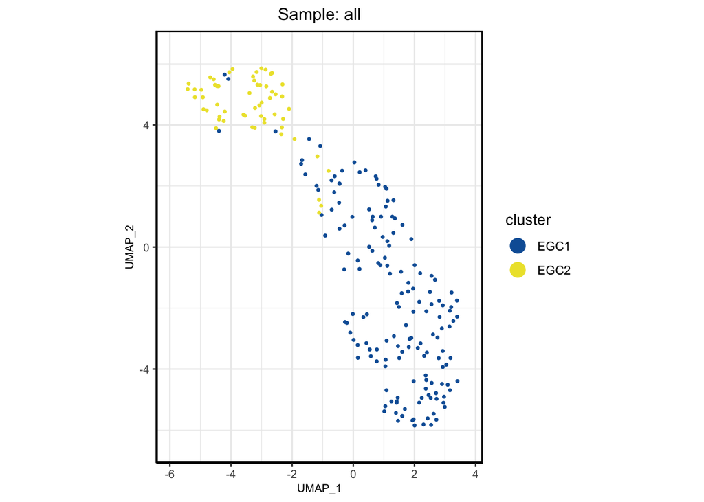

**Figure 1g:** EGCs upregulate transcriptional targets of IFN-gamma in response to inflammatory injury.An interactive version of this figure can be found here.

### Figure_1h

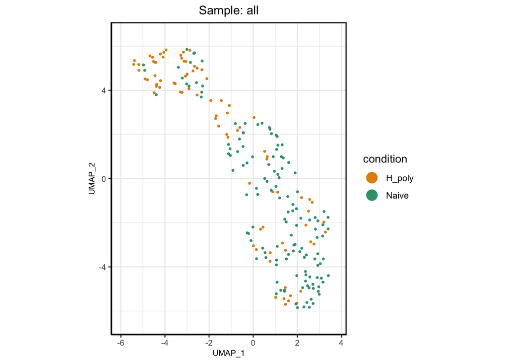

**Figure 1h:** EGCs upregulate transcriptional targets of IFN-gamma in response to inflammatory injury.An interactive version of this figure can be found here.

### Figure_1i

[figure not shown]

### Figure_EDF2f

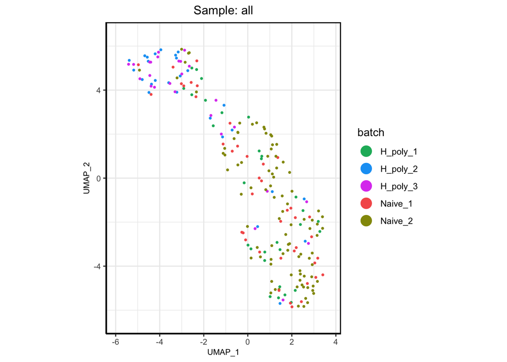

**Figure EDF2f:** Transcriptional analysis of the TM after H. polyinfection. UMAP of EGCs isolated from the TM of naïve and H. polyinfected mice and subjected to single cell RNAseq. Cells are color-coded according to experiments (batches).An interactive version of this figure can be found here.

## Main Single Cell Experiment

```r
cat(paste(knitr::knit(text = chnkVec, quiet = T), collapse = "\n"))
```

### Figure_3bcij

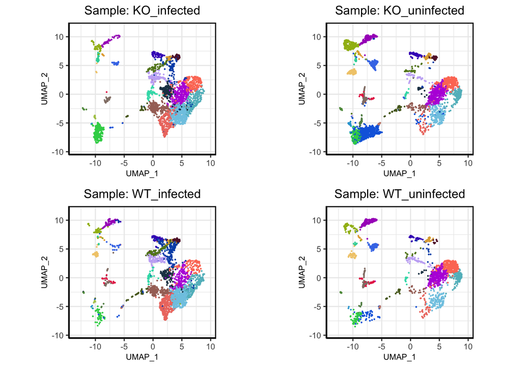

**Figure 3bcij:** IFN-γ-signaling in EGCs regulates non cell autonomously the immune state of intestinal TMat homeostasis and following H. polyinfection. UMAP of sequenced TM cells from naïve Ifngr2CTRLand Ifngr2ΔEGCmice.UMAP of sequenced TM cells from H. poly-infected Ifngr2CTRLand Ifngr2ΔEGCmice. Identity of cell clusters can be indicated by ticking the show legends box.An interactive version of this figure can be found here.

### Figure_3_Lcn2_UMAP

[figure not shown]

**Figure 3 Lcn2 UMAP:** IFN-γ-signaling in EGCs regulates non cell autonomously the immune state of intestinal TMat homeostasis and following H. polyinfection. UMAP of lg10 Lcn2 expressionAn interactive version of this figure can be found here.

### Figure_4_Lcn2_Violin

[figure not shown]

## Main Single Cell Experiment - Fibroblast Subclustering

```r
cat(paste(knitr::knit(text = chnkVec, quiet = T), collapse = "\n"))
```

### Figure_EDF5

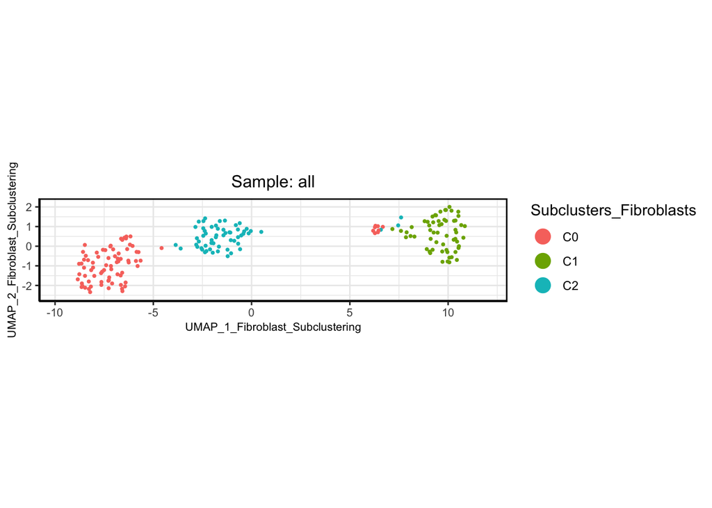

**Figure EDF5:** Fibroblast Sub-clustering of the main single-cell experiment.An interactive version of this figure can be found here.

### Figure_EDF5_Pdgfra_UMAP

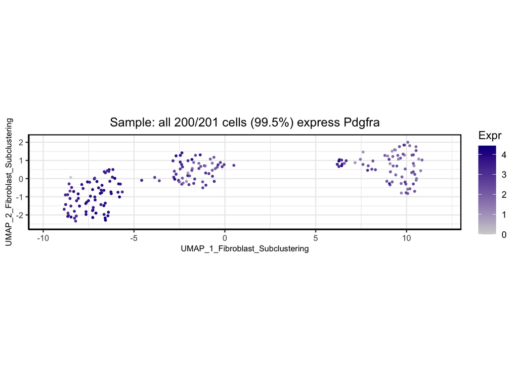

**Figure EDF5 Pdgfra UMAP:** Fibroblast Sub-clustering of the main single-cell experiment. Expression intensity for Pdgfra is highlighted as an example.An interactive version of this figure can be found here.

### Figure_EDF5_Pdgfra_Violin

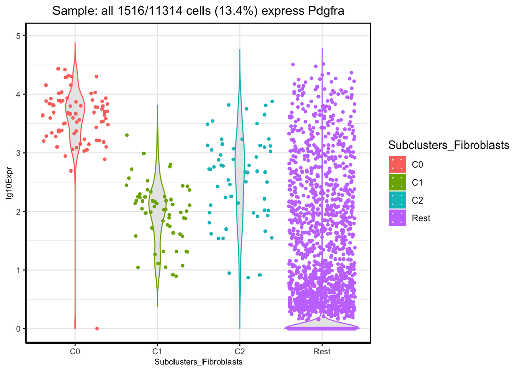

**Figure EDF5 Pdgfra Violin:** TFibroblast Sub-clustering of the main single-cell experiment. Violing plot for Pdgfra as an example.An interactive version of this figure can be found here.